# HW3

```r
library(tidyverse)
library(tidymodels)
```

```r
library(ggplot2)
library(corrplot)
library(dplyr)
library(corrr)
library(MASS)
library(discrim)
library(klaR)
```

# Importing the dataset

```r
titanic <- read.csv('data/titanic.csv')
titanic$survived <- as.factor(titanic$survived)
titanic$pclass <- as.factor(titanic$pclass)
```

# Q1

```r
set.seed(3435)
titanic_split <- initial_split(titanic, prop = 0.7,
                               strata = survived)
titanic_testing <- testing(titanic_split)
titanic_training <- training(titanic_split)
head(titanic_training)
```

```
##    passenger_id survived pclass                                 name    sex age
## 1             1       No      3              Braund, Mr. Owen Harris   male  22
## 5             5       No      3             Allen, Mr. William Henry   male  35
## 7             7       No      1              McCarthy, Mr. Timothy J   male  54
## 8             8       No      3       Palsson, Master. Gosta Leonard   male   2
## 14           14       No      3          Andersson, Mr. Anders Johan   male  39
## 15           15       No      3 Vestrom, Miss. Hulda Amanda Adolfina female  14
##    sib_sp parch    ticket    fare cabin embarked
## 1       1     0 A/5 21171  7.2500  <NA>        S
## 5       0     0    373450  8.0500  <NA>        S
## 7       0     0     17463 51.8625   E46        S
## 8       3     1    349909 21.0750  <NA>        S
## 14      1     5    347082 31.2750  <NA>        S
## 15      0     0    350406  7.8542  <NA>        S
```

The proportion of the training data I chose is 0.7 so that there will be 623 observations for the training set which is enough for building the model. There will be 268 observations for the testing set which is enough to test the validity of the model.

The training data set includes missing data. There are a few observations that are missing the data for variable ‘age’. Also, most of the observations are missing the data for variable ‘cabin’, so it is reasonable to exclude this variable while building the ML model.

By stratifying on the outcome variable, ‘survived’, we are able to ensure that the proportion of the survived individuals and the dead individuals are the same in both the training set and the testing set.

# Q2

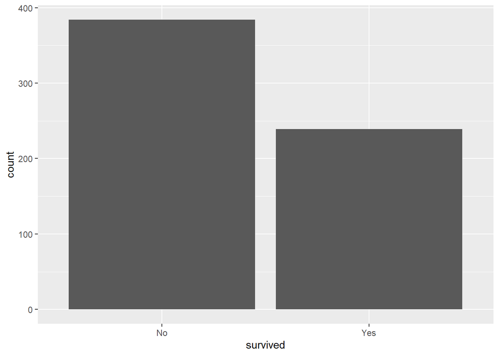

```r
ggplot(data = titanic_training, aes(x = survived)) + geom_bar()
```

In the training set, the number of individuals who survived is approximately 240 while the number of individuals who died is approximately 380. In other words, the amount of people who survived is approximately 2/3 of the people who died.

# Q3

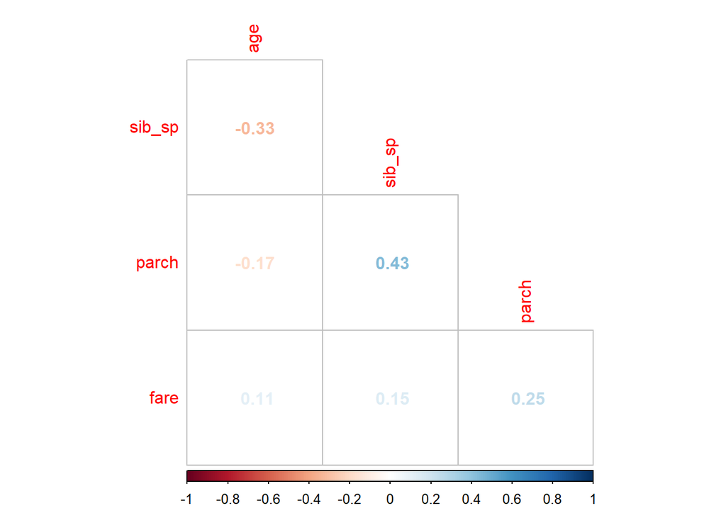

```r
titanic_cor <- titanic_training %>% dplyr :: select(age, sib_sp, parch, fare)
cor_matrix <- cor(titanic_cor, use="pairwise.complete.obs")
corrplot(cor_matrix, method = 'number', type = 'lower', diag = F)
```

From the correlation matrix, we can see there is no strong correlations between the variables. The strongest correlation is between parch and sib_sp with a value of 0.43.

# Q4

```r
titanic_training2 <- titanic_training %>% dplyr :: select(survived,
                                                          pclass, sex, age, sib_sp, parch, fare)
titanic_recipe <- recipe(survived ~ ., data = titanic_training2) %>%
                  step_impute_linear(age)
titanic_recipe <- titanic_recipe %>% step_dummy(sex)
titanic_recipe <- step_interact(titanic_recipe, terms = ~ fare : starts_with('sex'))
titanic_recipe <- step_interact(titanic_recipe, terms = ~ age : fare)

titanic_recipe
```

```
## Recipe
##
## Inputs:
##
##       role #variables
##    outcome          1
##  predictor          6
##
## Operations:
##
## Linear regression imputation for age
## Dummy variables from sex
## Interactions with fare:starts_with("sex")
## Interactions with age:fare
```

# Q5

```r
logistic_model <- logistic_reg() %>% set_engine('glm') %>% set_mode('classification')
logistic_workflow <- workflow() %>% add_model(logistic_model) %>% add_recipe(titanic_recipe)
logistic_fit <- fit(logistic_workflow, titanic_training2)
```

# Q6

```r
lda_model <- discrim_linear() %>% set_engine('MASS') %>% set_mode('classification')
lda_workflow <- workflow() %>% add_model(lda_model) %>% add_recipe(titanic_recipe)
lda_fit <- fit(lda_workflow, titanic_training2)
```

# Q7

```r
qda_model <- discrim_quad() %>% set_engine('MASS') %>% set_mode('classification')
qda_workflow <- workflow() %>% add_model(qda_model) %>% add_recipe(titanic_recipe)
qda_fit <- fit(qda_workflow, titanic_training2)
```

# Q8

```r
nb_model <- naive_Bayes() %>% set_engine('klaR') %>% set_mode('classification') %>%
            set_args(usekernel = F)
nb_workflow <- workflow() %>% add_model(nb_model) %>% add_recipe(titanic_recipe)
nb_fit <- fit(nb_workflow, titanic_training2)
```

# Q9

```r
predict(logistic_fit, new_data = titanic_training2, type = "class")
```

```
## # A tibble: 623 x 1
##    .pred_class
##    <fct>
##  1 No
##  2 No
##  3 No
##  4 No
##  5 No
##  6 Yes
##  7 No
##  8 No
##  9 Yes
## 10 No
## # ... with 613 more rows
```

```r
logistic_acc <- augment(logistic_fit, new_data = titanic_training2)
accuracy(data = logistic_acc, truth = survived, estimate = .pred_class)
```

```
## # A tibble: 1 x 3
##   .metric  .estimator .estimate
##   <chr>    <chr>          <dbl>
## 1 accuracy binary         0.814
```

```r
predict(lda_fit, new_data = titanic_training2, type = "class")
```

```
## # A tibble: 623 x 1
##    .pred_class
##    <fct>
##  1 No
##  2 No
##  3 No
##  4 No
##  5 No
##  6 Yes
##  7 No
##  8 Yes
##  9 Yes
## 10 No
## # ... with 613 more rows
```

```r
lda_acc <- augment(lda_fit, new_data = titanic_training2)
accuracy(data = lda_acc, truth = survived, estimate = .pred_class)
```

```
## # A tibble: 1 x 3
##   .metric  .estimator .estimate
##   <chr>    <chr>          <dbl>
## 1 accuracy binary         0.793
```

```r
predict(qda_fit, new_data = titanic_training2, type = "class")
```

```
## # A tibble: 623 x 1
##    .pred_class
##    <fct>
##  1 No
##  2 No
##  3 No
##  4 No
##  5 No
##  6 Yes
##  7 No
##  8 No
##  9 No
## 10 Yes
## # ... with 613 more rows
```

```r
qda_acc <- augment(qda_fit, new_data = titanic_training2)
accuracy(data = qda_acc, truth = survived, estimate = .pred_class)
```

```
## # A tibble: 1 x 3
##   .metric  .estimator .estimate
##   <chr>    <chr>          <dbl>
## 1 accuracy binary         0.778
```

```r
predict(nb_fit, new_data = titanic_training2, type = "class")
```

```
## # A tibble: 623 x 1
##    .pred_class
##    <fct>
##  1 No
##  2 No
##  3 No
##  4 No
##  5 No
##  6 Yes
##  7 No
##  8 Yes
##  9 No
## 10 Yes
## # ... with 613 more rows
```

```r
nb_acc <- augment(nb_fit, new_data = titanic_training2)
accuracy(data = nb_acc, truth = survived, estimate = .pred_class)
```

```
## # A tibble: 1 x 3
##   .metric  .estimator .estimate
##   <chr>    <chr>          <dbl>
## 1 accuracy binary         0.780
```

Conclusion: The logistic regression model has the highest accuracy among all four models.

# Q10

```r
titanic_testing2 <- titanic_testing %>% dplyr::select(survived,
                                                      pclass, sex, age, sib_sp, parch, fare)
predict(logistic_fit, new_data = titanic_testing2, type = "class")
```

```
## # A tibble: 268 x 1
##    .pred_class
##    <fct>
##  1 Yes
##  2 Yes
##  3 No
##  4 No
##  5 No
##  6 No
##  7 No
##  8 No
##  9 No
## 10 No
## # ... with 258 more rows
```

```r
logistic_acc_test <- augment(logistic_fit, new_data = titanic_testing2)
accuracy(data = logistic_acc_test, truth = survived, estimate = .pred_class)
```

```
## # A tibble: 1 x 3
##   .metric  .estimator .estimate
##   <chr>    <chr>          <dbl>
## 1 accuracy binary         0.832
```

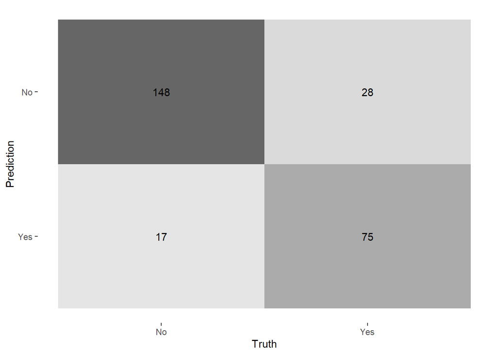

```r
conf_mat(data = logistic_acc_test, truth = survived, estimate = .pred_class) %>%
autoplot(type = "heatmap")
```

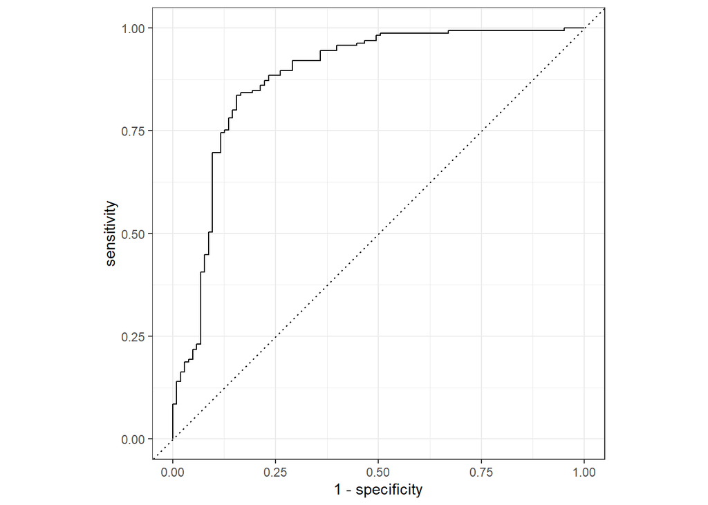

```r
roc_curve(logistic_acc_test, truth = survived, estimate = .pred_No) %>%
autoplot()
```

```r
roc_auc(logistic_acc_test, truth = survived, .pred_No)
```

```
## # A tibble: 1 x 3
##   .metric .estimator .estimate
##   <chr>   <chr>          <dbl>
## 1 roc_auc binary         0.880
```

The accuracy of the model on the testing data is 0.8320896 which means the model is performing quite well. The accuracy of the model on the training set and the testing set are different primarily because the number of observations in each set is different.